Name: Sajjad Alizadeh

STD number: 810197547

Subject: AI-CA4

# Phase 0

```python
import pandas as pd

train_data = pd.read_csv("train.csv")
```

داده تمرین به شکل زیر است:

```python
train_data
```

|  | Id | MSSubClass | MSZoning | LotFrontage | LotArea | Street | Alley | LotShape | LandContour | Utilities | ... | PoolArea | PoolQC | Fence | MiscFeature | MiscVal | MoSold | YrSold | SaleType | SaleCondition | SalePrice |
| --- | --- | --- | --- | --- | --- | --- | --- | --- | --- | --- | --- | --- | --- | --- | --- | --- | --- | --- | --- | --- | --- |
| 0 | 1 | 60 | RL | 65.0 | 8450 | Pave | NaN | Reg | Lvl | AllPub | ... | 0 | NaN | NaN | NaN | 0 | 2 | 2008 | WD | Normal | 208500 |
| 1 | 2 | 20 | RL | 80.0 | 9600 | Pave | NaN | Reg | Lvl | AllPub | ... | 0 | NaN | NaN | NaN | 0 | 5 | 2007 | WD | Normal | 181500 |
| 2 | 3 | 60 | RL | 68.0 | 11250 | Pave | NaN | IR1 | Lvl | AllPub | ... | 0 | NaN | NaN | NaN | 0 | 9 | 2008 | WD | Normal | 223500 |
| 3 | 4 | 70 | RL | 60.0 | 9550 | Pave | NaN | IR1 | Lvl | AllPub | ... | 0 | NaN | NaN | NaN | 0 | 2 | 2006 | WD | Abnorml | 140000 |
| 4 | 5 | 60 | RL | 84.0 | 14260 | Pave | NaN | IR1 | Lvl | AllPub | ... | 0 | NaN | NaN | NaN | 0 | 12 | 2008 | WD | Normal | 250000 |
| ... | ... | ... | ... | ... | ... | ... | ... | ... | ... | ... | ... | ... | ... | ... | ... | ... | ... | ... | ... | ... | ... |
| 1455 | 1456 | 60 | RL | 62.0 | 7917 | Pave | NaN | Reg | Lvl | AllPub | ... | 0 | NaN | NaN | NaN | 0 | 8 | 2007 | WD | Normal | 175000 |
| 1456 | 1457 | 20 | RL | 85.0 | 13175 | Pave | NaN | Reg | Lvl | AllPub | ... | 0 | NaN | MnPrv | NaN | 0 | 2 | 2010 | WD | Normal | 210000 |
| 1457 | 1458 | 70 | RL | 66.0 | 9042 | Pave | NaN | Reg | Lvl | AllPub | ... | 0 | NaN | GdPrv | Shed | 2500 | 5 | 2010 | WD | Normal | 266500 |
| 1458 | 1459 | 20 | RL | 68.0 | 9717 | Pave | NaN | Reg | Lvl | AllPub | ... | 0 | NaN | NaN | NaN | 0 | 4 | 2010 | WD | Normal | 142125 |
| 1459 | 1460 | 20 | RL | 75.0 | 9937 | Pave | NaN | Reg | Lvl | AllPub | ... | 0 | NaN | NaN | NaN | 0 | 6 | 2008 | WD | Normal | 147500 |

1460 rows × 81 columns

حال با استفاده از متدهای info و describe اطلاعاتی در مورد داده تمرین مشاهده میکنیم و در نهایت درصد داده های از دست رفته هر ویژگی را چاپ میکنیم

```python
train_data.describe()
```

|  | Id | MSSubClass | LotFrontage | LotArea | OverallQual | OverallCond | YearBuilt | YearRemodAdd | MasVnrArea | BsmtFinSF1 | ... | WoodDeckSF | OpenPorchSF | EnclosedPorch | 3SsnPorch | ScreenPorch | PoolArea | MiscVal | MoSold | YrSold | SalePrice |
| --- | --- | --- | --- | --- | --- | --- | --- | --- | --- | --- | --- | --- | --- | --- | --- | --- | --- | --- | --- | --- | --- |
| count | 1460.000000 | 1460.000000 | 1201.000000 | 1460.000000 | 1460.000000 | 1460.000000 | 1460.000000 | 1460.000000 | 1452.000000 | 1460.000000 | ... | 1460.000000 | 1460.000000 | 1460.000000 | 1460.000000 | 1460.000000 | 1460.000000 | 1460.000000 | 1460.000000 | 1460.000000 | 1460.000000 |
| mean | 730.500000 | 56.897260 | 70.049958 | 10516.828082 | 6.099315 | 5.575342 | 1971.267808 | 1984.865753 | 103.685262 | 443.639726 | ... | 94.244521 | 46.660274 | 21.954110 | 3.409589 | 15.060959 | 2.758904 | 43.489041 | 6.321918 | 2007.815753 | 180921.195890 |
| std | 421.610009 | 42.300571 | 24.284752 | 9981.264932 | 1.382997 | 1.112799 | 30.202904 | 20.645407 | 181.066207 | 456.098091 | ... | 125.338794 | 66.256028 | 61.119149 | 29.317331 | 55.757415 | 40.177307 | 496.123024 | 2.703626 | 1.328095 | 79442.502883 |
| min | 1.000000 | 20.000000 | 21.000000 | 1300.000000 | 1.000000 | 1.000000 | 1872.000000 | 1950.000000 | 0.000000 | 0.000000 | ... | 0.000000 | 0.000000 | 0.000000 | 0.000000 | 0.000000 | 0.000000 | 0.000000 | 1.000000 | 2006.000000 | 34900.000000 |
| 25% | 365.750000 | 20.000000 | 59.000000 | 7553.500000 | 5.000000 | 5.000000 | 1954.000000 | 1967.000000 | 0.000000 | 0.000000 | ... | 0.000000 | 0.000000 | 0.000000 | 0.000000 | 0.000000 | 0.000000 | 0.000000 | 5.000000 | 2007.000000 | 129975.000000 |
| 50% | 730.500000 | 50.000000 | 69.000000 | 9478.500000 | 6.000000 | 5.000000 | 1973.000000 | 1994.000000 | 0.000000 | 383.500000 | ... | 0.000000 | 25.000000 | 0.000000 | 0.000000 | 0.000000 | 0.000000 | 0.000000 | 6.000000 | 2008.000000 | 163000.000000 |
| 75% | 1095.250000 | 70.000000 | 80.000000 | 11601.500000 | 7.000000 | 6.000000 | 2000.000000 | 2004.000000 | 166.000000 | 712.250000 | ... | 168.000000 | 68.000000 | 0.000000 | 0.000000 | 0.000000 | 0.000000 | 0.000000 | 8.000000 | 2009.000000 | 214000.000000 |
| max | 1460.000000 | 190.000000 | 313.000000 | 215245.000000 | 10.000000 | 9.000000 | 2010.000000 | 2010.000000 | 1600.000000 | 5644.000000 | ... | 857.000000 | 547.000000 | 552.000000 | 508.000000 | 480.000000 | 738.000000 | 15500.000000 | 12.000000 | 2010.000000 | 755000.000000 |

8 rows × 38 columns

```python
train_data.info()
```

```
<class 'pandas.core.frame.DataFrame'>
RangeIndex: 1460 entries, 0 to 1459
Data columns (total 81 columns):
 #   Column         Non-Null Count  Dtype
---  ------         --------------  -----
 0   Id             1460 non-null   int64
 1   MSSubClass     1460 non-null   int64
 2   MSZoning       1460 non-null   object
 3   LotFrontage    1201 non-null   float64
 4   LotArea        1460 non-null   int64
 5   Street         1460 non-null   object
 6   Alley          91 non-null     object
 7   LotShape       1460 non-null   object
 8   LandContour    1460 non-null   object
 9   Utilities      1460 non-null   object
```

[output cut: 73 more lines]

```python
for i in train_data.columns:
    print("Nulls (Percent)", i, ":", 1 - train_data.notnull()[i].sum() / 1460)
```

```
Nulls (Percent) Id : 0.0
Nulls (Percent) MSSubClass : 0.0
Nulls (Percent) MSZoning : 0.0
Nulls (Percent) LotFrontage : 0.17739726027397262
Nulls (Percent) LotArea : 0.0
Nulls (Percent) Street : 0.0
Nulls (Percent) Alley : 0.9376712328767123
Nulls (Percent) LotShape : 0.0
Nulls (Percent) LandContour : 0.0
Nulls (Percent) Utilities : 0.0
Nulls (Percent) LotConfig : 0.0
Nulls (Percent) LandSlope : 0.0
Nulls (Percent) Neighborhood : 0.0
Nulls (Percent) Condition1 : 0.0
Nulls (Percent) Condition2 : 0.0
Nulls (Percent) BldgType : 0.0
Nulls (Percent) HouseStyle : 0.0
Nulls (Percent) OverallQual : 0.0
Nulls (Percent) OverallCond : 0.0
Nulls (Percent) YearBuilt : 0.0
Nulls (Percent) YearRemodAdd : 0.0
Nulls (Percent) RoofStyle : 0.0
Nulls (Percent) RoofMatl : 0.0
Nulls (Percent) Exterior1st : 0.0
Nulls (Percent) Exterior2nd : 0.0
Nulls (Percent) MasVnrType : 0.005479452054794498
Nulls (Percent) MasVnrArea : 0.005479452054794498
Nulls (Percent) ExterQual : 0.0
Nulls (Percent) ExterCond : 0.0
Nulls (Percent) Foundation : 0.0
Nulls (Percent) BsmtQual : 0.025342465753424692
Nulls (Percent) BsmtCond : 0.025342465753424692
Nulls (Percent) BsmtExposure : 0.02602739726027392
Nulls (Percent) BsmtFinType1 : 0.025342465753424692
Nulls (Percent) BsmtFinSF1 : 0.0
Nulls (Percent) BsmtFinType2 : 0.02602739726027392
Nulls (Percent) BsmtFinSF2 : 0.0
Nulls (Percent) BsmtUnfSF : 0.0
Nulls (Percent) TotalBsmtSF : 0.0
Nulls (Percent) Heating : 0.0
```

[output cut: 26 more lines]

```
Nulls (Percent) WoodDeckSF : 0.0
Nulls (Percent) OpenPorchSF : 0.0
Nulls (Percent) EnclosedPorch : 0.0
Nulls (Percent) 3SsnPorch : 0.0
Nulls (Percent) ScreenPorch : 0.0
Nulls (Percent) PoolArea : 0.0
Nulls (Percent) PoolQC : 0.9952054794520548
Nulls (Percent) Fence : 0.8075342465753425
Nulls (Percent) MiscFeature : 0.963013698630137
Nulls (Percent) MiscVal : 0.0
Nulls (Percent) MoSold : 0.0
Nulls (Percent) YrSold : 0.0
Nulls (Percent) SaleType : 0.0
Nulls (Percent) SaleCondition : 0.0
Nulls (Percent) SalePrice : 0.0
```

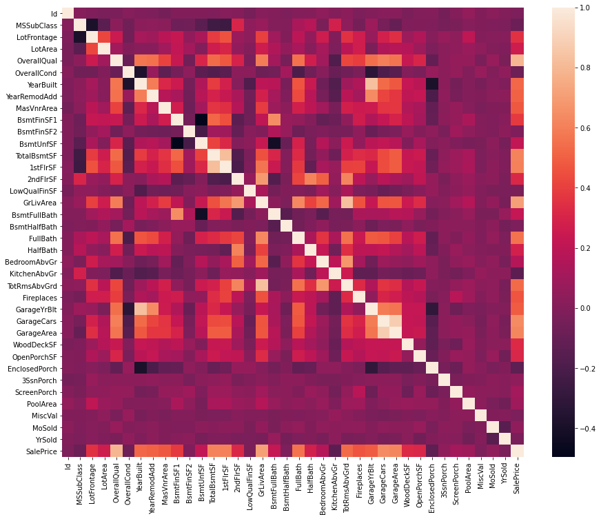

```python
import seaborn as sns
import matplotlib.pyplot as plt

plt.figure(figsize=(15,12))
sns.heatmap(train_data.corr())
```

هیت مپ بالا بر اساس همبستگی میان feature ها است. برای انتخاب feature ها بهتر است آنهایی انتخاب شوند که همبستگی کمتری دارند. زیرا اطلاعات بیشتری به ما میدهند. یعنی تفاوت میان دو داده بیشتر مشخص میشود. feature هایی با همبستگی بیشتر وابسته تر هستند و میتوان یکی از آنها را دراپ کرد.  
چهار feature انتخاب شده:  
EnclosedPorch - YearBuilt - MSSubClass - LotFrontage

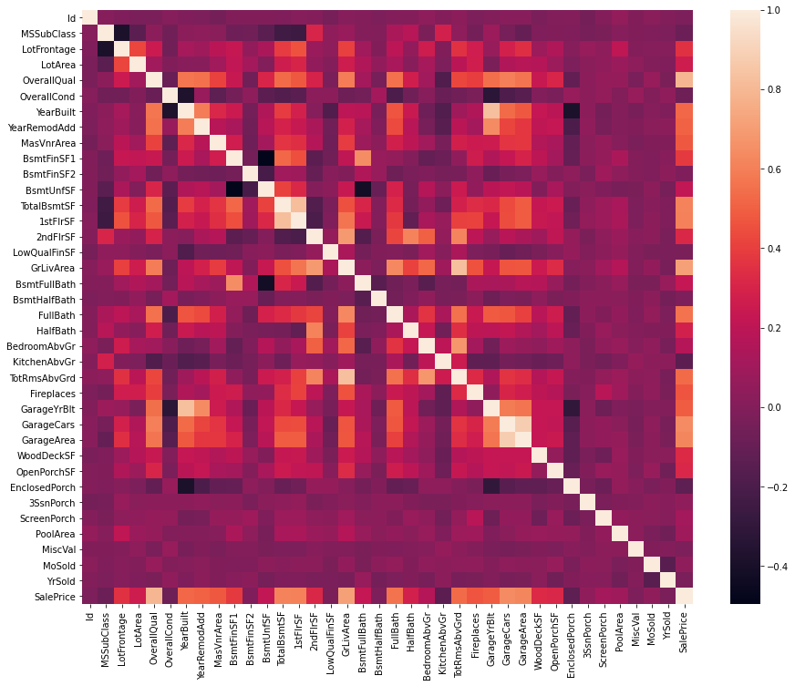

```python
import copy
import numpy as np
import seaborn as sns
import matplotlib.pyplot as plt

plt.figure(figsize=(15,12))
log_price_data = copy.deepcopy(train_data)
log_price_data['SalePrice'] = np.log2(log_price_data['SalePrice'])
sns.heatmap(train_data.corr())
```

به طور کلی نمیتوان میزان همبستگی را به تنهایی به عنوان معیاری برای انتخاب فیچرها در نظر گرفت. مثلا میگوییم اگر اختلاف همبستگی دو فیچر از ۰.۹ بیشتر بود یکی از آنها دراپ شود. این عدد ۰.۹ از کجا می آید؟ البته که میتوان با سعی و خطا و ایجاد مدلهای مختلف مقدار مناسب را پیدا کرد ولی فرایندی وقت گیر است. از دلایل دیگر میتوان به پرت بودن فیچر مورد نظر اشاره کرد. مثلا فرض کنید یک فیچر به لیست فیچرها اضافه میکنیم و مقدار آن را به صورت رندوم میگذاریم. احتمالا همبستگی این فیچر با سایر فیچرها کم خواهد بود. (زیرا واقعا به فیچرهای دیگر ربطی ندارد) اما وجود این فیچر ممکن است مدل ما را خراب کند. زیرا مقدار آن برای تمام داده آموزش یکی است. فلذا انتخاب فقط بر اساس همبستگی کافی نیست. میتوان از کارهای دیگری مانند p-value استفاده کرد.

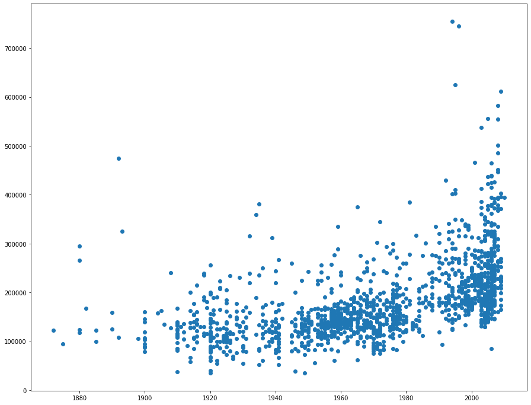

```python
import seaborn as sns
import matplotlib.pyplot as plt

plt.figure(figsize=(15,12))
plt.scatter(train_data['YearBuilt'], train_data['SalePrice'])
```

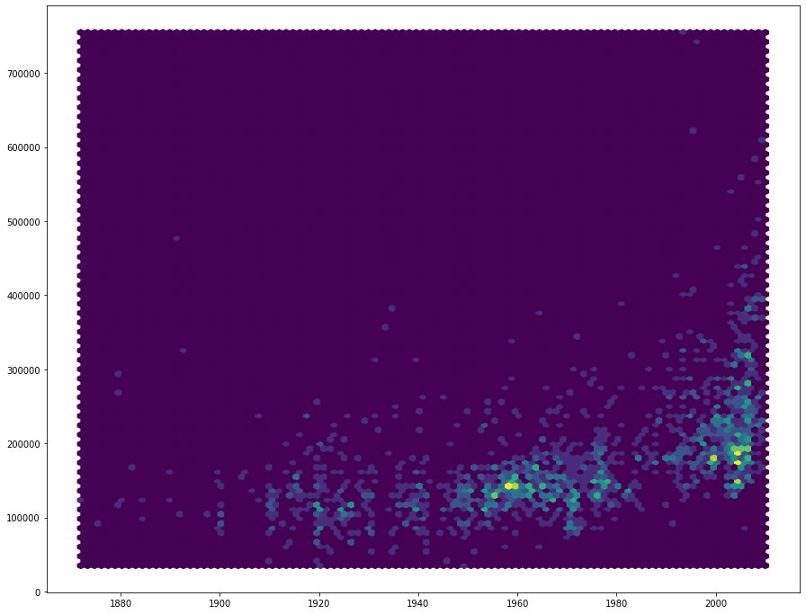

```python
import seaborn as sns
import matplotlib.pyplot as plt

plt.figure(figsize=(15,12))
plt.hexbin(train_data['YearBuilt'], train_data['SalePrice'])
```

در نمودارهای بالا نمودارهای hexbin و scatter برای YearBuilt و SalePrice نمایش داده شده است. همانطور که مشخص است با توجه به تراکم نقاط میتوان یک تابع نمایی یا حتی درجه دو برای مدل کردن استفاده کرد در نتیجه انتخاب خوبی بوده است.

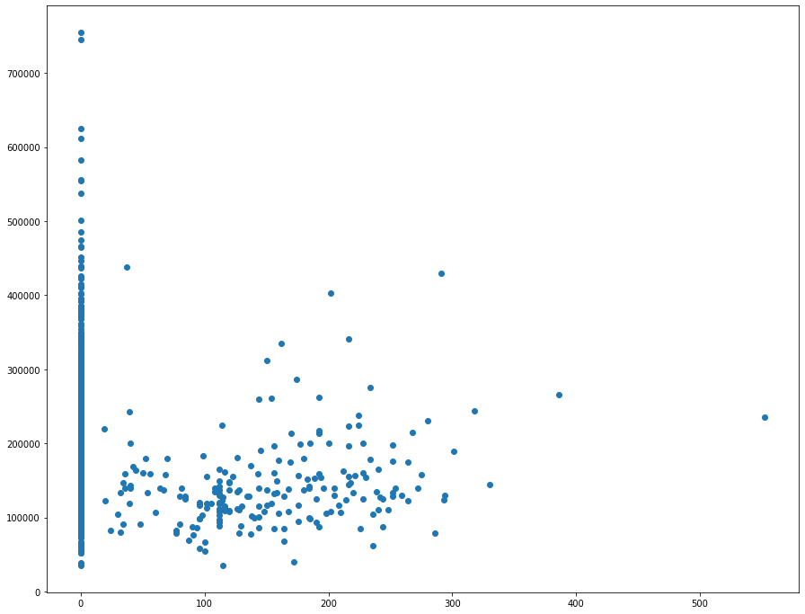

```python
import seaborn as sns
import matplotlib.pyplot as plt

plt.figure(figsize=(15,12))
plt.scatter(train_data['EnclosedPorch'], train_data['SalePrice'])
```

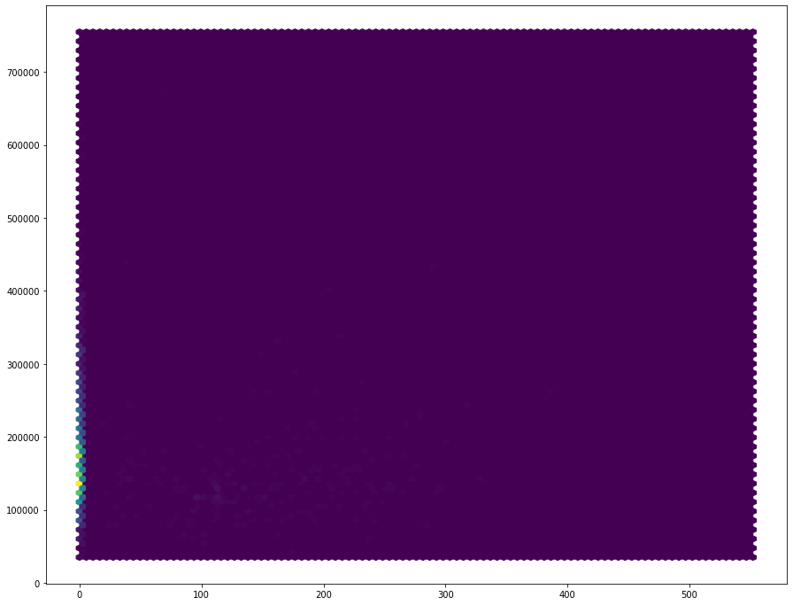

```python
import seaborn as sns
import matplotlib.pyplot as plt

plt.figure(figsize=(15,12))
plt.hexbin(train_data['EnclosedPorch'], train_data['SalePrice'])
```

در نمودارهای بالا نمودارهای hexbin و scatter برای EnclosedPorch و SalePrice نمایش داده شده است. همانطور که مشخص است با توجه به تراکم نقاط میتوان یک خط با شیب بی نهایت برای مدل کردن استفاده کرد در نتیجه انتخاب خوبی بوده است.

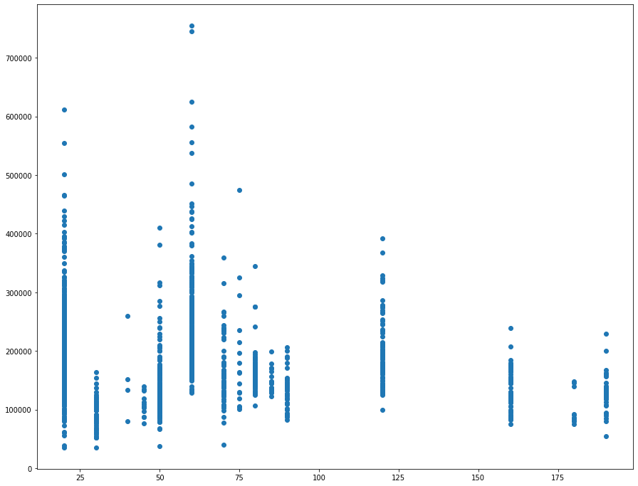

```python
import seaborn as sns
import matplotlib.pyplot as plt

plt.figure(figsize=(15,12))
plt.scatter(train_data['MSSubClass'], train_data['SalePrice'])
```

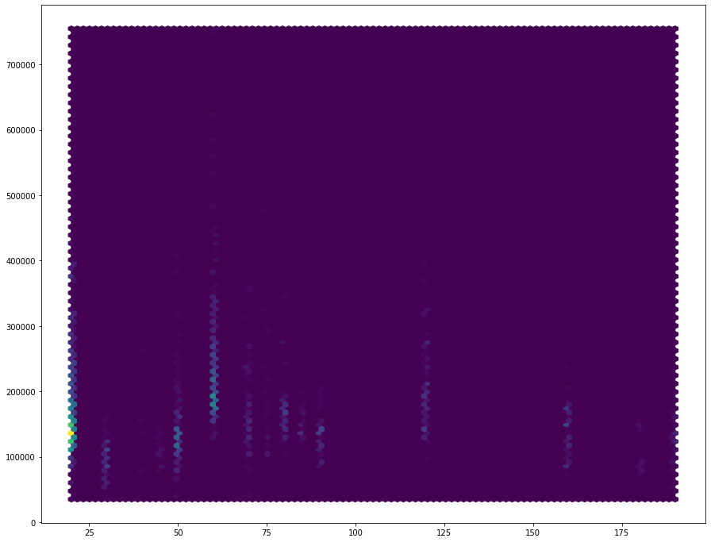

```python
import seaborn as sns
import matplotlib.pyplot as plt

plt.figure(figsize=(15,12))
plt.hexbin(train_data['MSSubClass'], train_data['SalePrice'])
```

در نمودارهای بالا نمودارهای hexbin و scatter برای MSSubClass و SalePrice نمایش داده شده است. همانطور که مشخص است با توجه به تراکم نقاط میتوان چند خط با شیب بی نهایت یا یک تابع درجه n برای مدل کردن استفاده کرد در نتیجه انتخاب خوبی بوده است.

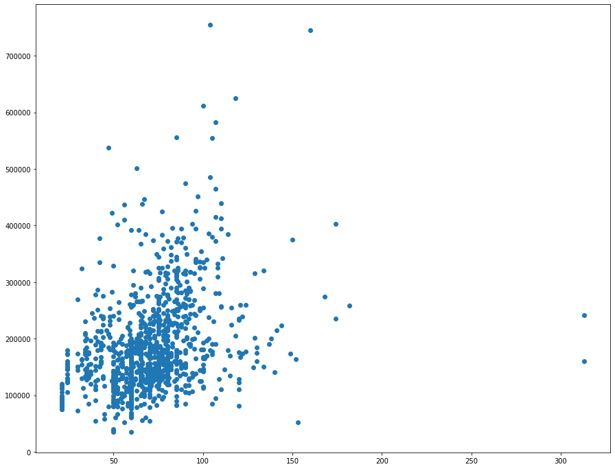

```python
import seaborn as sns
import matplotlib.pyplot as plt

plt.figure(figsize=(15,12))
plt.scatter(train_data['LotFrontage'], train_data['SalePrice'])
```

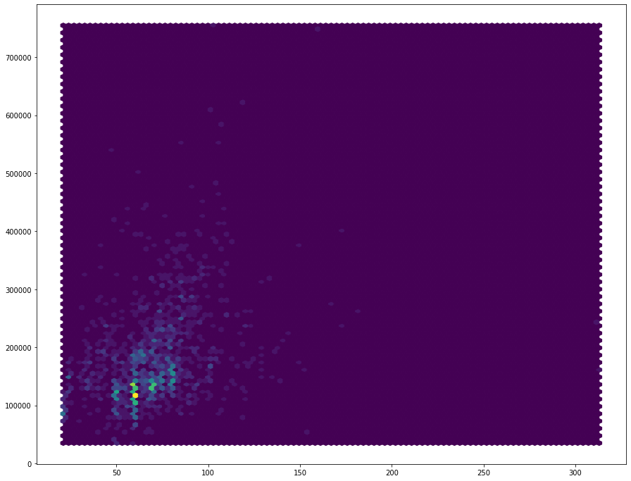

```python
import seaborn as sns
import matplotlib.pyplot as plt

plt.figure(figsize=(15,12))
plt.hexbin(train_data['LotFrontage'], train_data['SalePrice'])
```

در نمودارهای بالا نمودارهای hexbin و scatter برای LotFrontage و SalePrice نمایش داده شده است. همانطور که مشخص است با توجه به تراکم نقاط میتوان یک خط منحنی درجه سه برای مدل کردن استفاده کرد در نتیجه انتخاب خوبی بوده است.

سه ویژگی دسته ای که به نظر مهم هستند عبارت اند از: Neighborhood, RoofStyle, Foundation

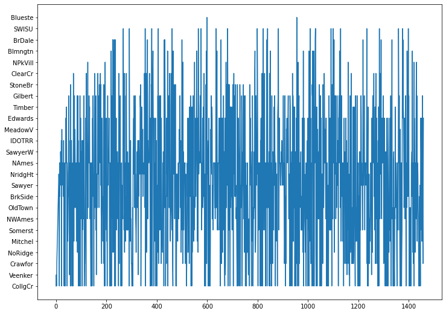

```python
import seaborn as sns
import matplotlib.pyplot as plt

plt.figure(figsize=(12,9))
plt.plot(train_data['Neighborhood'])
```

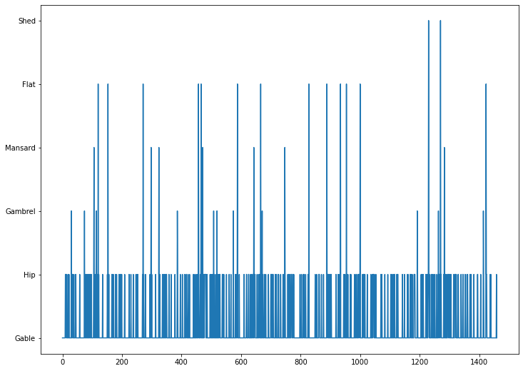

```python
import seaborn as sns
import matplotlib.pyplot as plt

plt.figure(figsize=(12,9))
plt.plot(train_data['RoofStyle'])
```

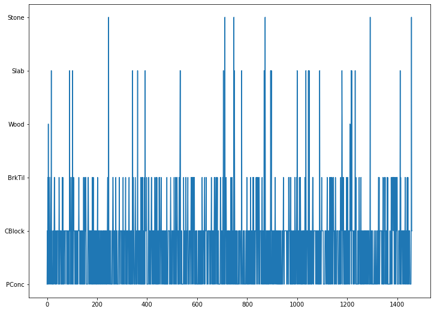

```python
import seaborn as sns
import matplotlib.pyplot as plt

plt.figure(figsize=(12,9))
plt.plot(train_data['Foundation'])
```

# Phase 1

روشهای زیر نیز برای پر کردن داده های گمشده وجود دارند:  
اول) Assigning An Unique Category: در داده های دسته ای اگر یک موجودیت وجود نداشت به جای آن یک نوع جدید گذاشته میشود. مثلا اگر فیچر سقف خانه ناقص بود به جای آن از یک کلاس جدید با نام unknown استفاده کرد. در این حالت کلاسهای جدید به دیتاست اضافه میشوند و در نتیجه واریانس تغییر میکند. نقطه ضعف این کار همینجاست. یعنی ممکن است اضافه کردن این کلاس جدید باعث شود کارایی لازم را نداشته باشیم. ولی خوبی آن این است که دیگر دسته ای از داده ها را به دلیل نقص از دست نمیدهیم  
دوم) Predicting The Missing Values: میتوان با فیچرهایی که خالی نیستند سایر فیچرها را پیشبینی کرد. به عنوان مثال استفاده از liner reggresion که با استفاده از ماتریس همبستگی میتواند در یک حلقه داده های از دست رفته را پیشبینی کند تا به دقت مورد نظر برسیم. در این روش برای پر کردن جاهای خالی یک منطق وجود دارد و این منطق unbiased است و این از ویژگی های مثبت آن است. از نقاط ضعف آن میتوان به این اشاره کرد که با داده های موجود نتوانیم پیش بینی مناسبی از داده های دیگر داشته باشیم. مثلا تعداد داده های موجود خیلی کم باشد و یا به دلیل استقلال پیش بینی ما نزدیک به رندوم شود.  
سوم) Using Algorithms Which Support Missing Values: استفاده از الگوریتم هایی که در حالاتی توانایی کار بر روی داده هایی که در بین آنها داده گمشده نیز وجود دارد. مانند KNN و یا Random forrest . از نکات مثبت آن میتوان گفت که دیگر پیش پردازشی بر روی داده های غیرموجود نمیکنیم و نقطه ضعف آن عدم پشتیبانی برخی مسائل از این الگوریتم هاست. مثلا اگر تعریف کردن فاصله بین دو نقطه در یک مسئله دشوار باشد نمیتوانیم از الگوریتم KNN استفاده کنیم

```python
total = train_data.isnull().sum().sort_values(ascending=False)
percent = (train_data.isnull().sum()/train_data.isnull().count()).sort_values(ascending=False)
missing = pd.concat([total, percent], axis=1, keys=['Count', 'Percent'])
missing.head(20)
```

|  | Count | Percent |
| --- | --- | --- |
| PoolQC | 1453 | 0.995205 |
| MiscFeature | 1406 | 0.963014 |
| Alley | 1369 | 0.937671 |
| Fence | 1179 | 0.807534 |
| FireplaceQu | 690 | 0.472603 |
| LotFrontage | 259 | 0.177397 |
| GarageCond | 81 | 0.055479 |
| GarageType | 81 | 0.055479 |
| GarageYrBlt | 81 | 0.055479 |
| GarageFinish | 81 | 0.055479 |
| GarageQual | 81 | 0.055479 |
| BsmtExposure | 38 | 0.026027 |
| BsmtFinType2 | 38 | 0.026027 |
| BsmtFinType1 | 37 | 0.025342 |
| BsmtCond | 37 | 0.025342 |
| BsmtQual | 37 | 0.025342 |
| MasVnrArea | 8 | 0.005479 |
| MasVnrType | 8 | 0.005479 |
| Electrical | 1 | 0.000685 |
| Utilities | 0 | 0.000000 |

```python
# this is option one.
#train_data = train_data.drop(columns=['PoolQC', 'MiscFeature', 'Alley', 'Fence', 'FireplaceQu'])
for i in ['LotFrontage', 'MasVnrArea', 'GarageYrBlt']:
    train_data[i].fillna(train_data[i].mean(), inplace=True)
for i in ['MasVnrType', 'Electrical']:
    train_data[i].fillna(train_data[i].value_counts().index[0], inplace=True)
for i in train_data:
    train_data[i].fillna("NO_DATA", inplace=True)
```

نرمالیزه کردن باعث میشود تمام داده ها بین صفر و یک شوند. این کار به منظور رسیدن به یک مقیاس مشترک انجام میپذیرد. نرمالیزه کردن هنگامی که ما توزیع داده ها را نمیدانیم یا اینکه نمیدانیم توزیع گاوسی هستند یا خیر مناسب است و برای الگوریتم هایی که هیچ توزیعی را فرض نمیکنند مناسب است. مانند KNN  
استاندارد کردن هنگامی که توزیع داده گاوسی باشد یا الگوریتم هایی که استفاده میکنیم این فرض را داشته باشند مناسب است. یعنی تاثیر آن در این حالت بیشتر است. استاندارد کردن به منظور اینکه توزیع شبیه به توزیع گاوسی شود انجام میپذیرد.  
در این پروژه از آنجایی که توزیع داده ها را نمیدانیم خوب است داده ها نرمالایز شوند.

برای هندل کردن داده های دسته ای سه روش زیر را بیان میکنیم:  
اول) Integer Encoding: برای وقتی که هر فیچر به یک اینتجر مپ شده است  
دوم) One Hot Encoding: برای وقتی که هر فیچر به یک وکتور دودویی مپ شده است.  
سوم) Learned Embedding: هنگامی که توزیع دسته ها را میخواهیم یاد بگیریم. یعنی بسته به شرایط باید از متدهای مخصوص آن استفاده کرد.

همان طور که در فاز صفر گفته شد میتوان با استفاده از کورولیشن فیچرهایی که به یکدیگر وابسته هستند را شناسایی کرد و یکی از آنها را حذف کرد. مثلا فرض کنید در یک جدول قد به اینچ و قد به متر نگه داری میشود. واضح است که این دو به هم وابسته هستند. اگر یکی از آنها را حذف نکنیم تاثیر قد در مدل ما دوبرابر میشود که این مطلوب نیست. همچنین تعداد فیچرهای بالا میتواند پیچیدگی زمانی و پیاده سازی را بیشتر کند. فلذا بهتر است سعی کنیم تا جایی که میتوانیم فیچرهایی که از هم مستقل هستند را نگه داری کنیم.

معمولا این عدد را برابر ۸۰ یا ۶۷ یا ۵۰ در نظر میگیرند. بسته به هزینه محاسبات و کیفیت داده آموزش این مقدار میتواند متفاوت باشد. از متدهای دیگر میتوان به  
k-Fold Cross-Validation (k-Fold CV) Leave-one-out Cross-Validation (LOOCV) Nested Cross-Validation اشاره کرد.  
از نظر من تقسیم داده به صورت تصادفی به طور کلی کار خوبی نیست زیرا این عمل نیاز به آگاهی از نوع داده آموزش دارد. به عنوان مثال اگر کیفیت داده ها پایین باشد باید تعداد بالا باشد که با رندوم تقسیم کردن به این امر دست پیدا نمیکنیم. بهتر است تقسیم داده با منطق و یا سعی و خطا صورت پذیرد. البته اگر منظور از رندوم تقسیم کردن تکرار این عمل و استفاده از سعی و خطا است کار خوبی است ولی اگر فقط یکبار این کار را انجام دهیم خوب نیست.

# PHASE 2

#### KNN

```python
from sklearn.model_selection import train_test_split
from sklearn.neighbors import KNeighborsRegressor
from sklearn.metrics import mean_squared_error
from sklearn.metrics import mean_absolute_error
from sklearn.model_selection import GridSearchCV
from sklearn.model_selection import cross_val_score
from sklearn import preprocessing
import category_encoders as ce
import pandas as pd
import numpy as np

# read
train_data = pd.read_csv("train.csv")

# hande missing data
#train_data = train_data.drop(columns=['PoolQC', 'MiscFeature', 'Alley', 'Fence', 'FireplaceQu'])
for i in ['LotFrontage', 'MasVnrArea', 'GarageYrBlt']:
    train_data[i].fillna(train_data[i].mean(), inplace=True)
for i in ['MasVnrType', 'Electrical']:
    train_data[i].fillna(train_data[i].value_counts().index[0], inplace=True)
for i in train_data:
    train_data[i].fillna("NO_DATA", inplace=True)

# handle categorical data
categoricals = train_data.select_dtypes('object')
train_data = ce.OneHotEncoder(cols=categoricals).fit_transform(train_data)

# standardization and normalization
target = train_data['SalePrice'].values
data = train_data.iloc[:, :-1].values
min_max_scaler = preprocessing.MinMaxScaler()
x_scaled = min_max_scaler.fit_transform(data)
train_data = pd.DataFrame(x_scaled)

# split to train and test
x_train, x_test, y_train, y_test = train_test_split(x_scaled, target, test_size=0.25)

# KNN algorithm
error = [100000] * 4
MAEtrain = []
MAEtest = []
RMSEtrain = []
RMSEtest = []
xs = []
for i in range(2, 50):
    kNeighborsRegressor = KNeighborsRegressor(n_neighbors=i)
    kNeighborsRegressor.fit(x_train, y_train)
    train_prediction = kNeighborsRegressor.predict(x_train)
    test_prediction = kNeighborsRegressor.predict(x_test)
    MAEtrain.append(mean_absolute_error(train_prediction, y_train))
    MAEtest.append(mean_absolute_error(test_prediction, y_test))
    RMSEtrain.append(np.sqrt(mean_squared_error(train_prediction, y_train)))
    RMSEtest.append(np.sqrt(mean_squared_error(test_prediction, y_test)))
    if error[2] > mean_absolute_error(test_prediction, y_test):
        error[0] = mean_absolute_error(train_prediction, y_train)
        error[1] = np.sqrt(mean_squared_error(train_prediction, y_train))
        error[2] = mean_absolute_error(test_prediction, y_test)
        error[3] = np.sqrt(mean_squared_error(test_prediction, y_test))
    xs.append(i)

# print result
print("Train MAE: ", error[0])
print("Train RMSE: ", error[1])
print("######################################")
print("Test MAE: ", error[2])
print("Test RMSE: ", error[3])
```

```
Train MAE:  22480.641438356164
Train RMSE:  36931.7695794257
######################################
Test MAE:  23572.672260273972
Test RMSE:  36822.0463040557
```

در خروجی بالا نرمالیزه کردن و استاندارد کردن داده ها انجام شده است. برای داده های گمشده همانطور که در بخش قبل گغته شد انجام شده است و خروجی بالا بهترین خروجی ممکن است. همچنین داده آموزش بد مدل نمیشود و روی داده تست نیز خروجی مناسبی دارد پس دارای underfit یا overfit نیستیم. توجه کنید از تعداد همسایه ها از دو تا پنجاه گرفته شده است و کمترین میزان ارور داده تست به عنوان خروجی گزارش داده شده است.  
نمودارهای ارور بر حسب هایپرپارامتر این مسئله به شکل زیر است:

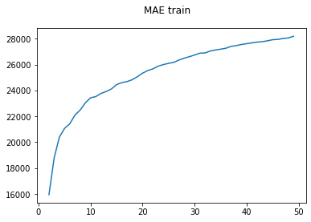

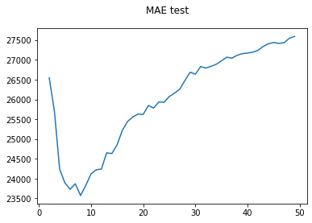

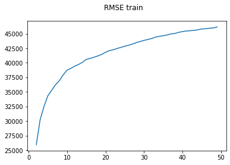

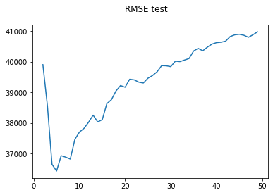

```python
import matplotlib.pyplot as plt
plt.figure().suptitle('MAE train')
plt.plot(xs, MAEtrain)
plt.figure().suptitle('MAE test')
plt.plot(xs, MAEtest)
plt.figure().suptitle('RMSE train')
plt.plot(xs, RMSEtrain)
plt.figure().suptitle('RMSE test')
plt.plot(xs, RMSEtest)
```

#### Decesion Tree

```python
from sklearn.tree import DecisionTreeRegressor

# read
train_data = pd.read_csv("train.csv")

# hande missing data
#train_data = train_data.drop(columns=['PoolQC', 'MiscFeature', 'Alley', 'Fence', 'FireplaceQu'])
for i in ['LotFrontage', 'MasVnrArea', 'GarageYrBlt']:
    train_data[i].fillna(train_data[i].mean(), inplace=True)
for i in ['MasVnrType', 'Electrical']:
    train_data[i].fillna(train_data[i].value_counts().index[0], inplace=True)
for i in train_data:
    train_data[i].fillna("NO_DATA", inplace=True)

# handle categorical data
categorical_columns = train_data.select_dtypes('object')
train_data = ce.OneHotEncoder(cols=categorical_columns, use_cat_names=True).fit_transform(train_data)

# standardization and normalization
x = train_data.iloc[:, :-1].values
target = train_data['SalePrice'].values
min_max_scaler = preprocessing.MinMaxScaler()
x_scaled = min_max_scaler.fit_transform(x)
train_data = pd.DataFrame(x_scaled)

# split to train and test
x_train, x_test, y_train, y_test = train_test_split(x_scaled, target, test_size=0.20)

# Decesion Tree algorithm
error = [100000] * 4
MAEtrain = []
MAEtest = []
RMSEtrain = []
RMSEtest = []
xs = []
for i in range(1, 100):
    decisionTreeRegressor = DecisionTreeRegressor(max_depth=i)
    decisionTreeRegressor.fit(x_train, y_train)
    train_prediction = decisionTreeRegressor.predict(x_train)
    test_prediction = decisionTreeRegressor.predict(x_test)
    MAEtrain.append(mean_absolute_error(train_prediction, y_train))
    MAEtest.append(mean_absolute_error(test_prediction, y_test))
    RMSEtrain.append(np.sqrt(mean_squared_error(train_prediction, y_train)))
    RMSEtest.append(np.sqrt(mean_squared_error(test_prediction, y_test)))
    if error[2] > mean_absolute_error(test_prediction, y_test):
        error[0] = mean_absolute_error(train_prediction, y_train)
        error[1] = np.sqrt(mean_squared_error(train_prediction, y_train))
        error[2] = mean_absolute_error(test_prediction, y_test)
        error[3] = np.sqrt(mean_squared_error(test_prediction, y_test))
    xs.append(i)

# print result
print("Train MAE: ", error[0])
print("Train RMSE: ", error[1])
print("######################################")
print("Test MAE: ", error[2])
print("Test RMSE: ", error[3])
```

```
Train MAE:  10997.298139200964
Train RMSE:  15131.026953904982
######################################
Test MAE:  23566.983024270005
Test RMSE:  36350.752806749704
```

در خروجی بالا نرمالیزه کردن و استاندارد کردن داده ها انجام شده است. برای داده های گمشده همانطور که در بخش قبل گغته شد انجام شده است و خروجی بالا بهترین خروجی ممکن است. همچنین داده آموزش به خوبی مدل شده است پس underfit نداریم. اما داده تست چندین برابر آموزش ارور دارد پس دارای overfit هستیم.  
نمودارهای ارور بر حسب هایپرپارامتر این مسئله به شکل زیر است:

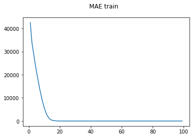

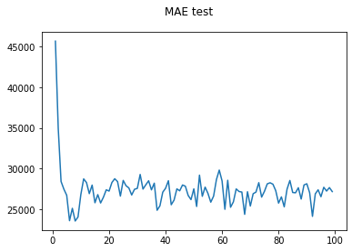

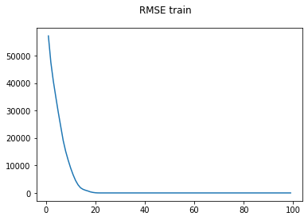

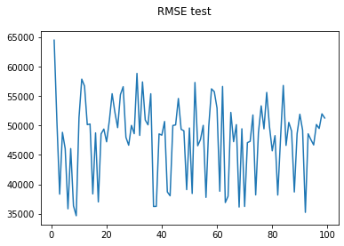

```python
import matplotlib.pyplot as plt
plt.figure().suptitle('MAE train')
plt.plot(xs, MAEtrain)
plt.figure().suptitle('MAE test')
plt.plot(xs, MAEtest)
plt.figure().suptitle('RMSE train')
plt.plot(xs, RMSEtrain)
plt.figure().suptitle('RMSE test')
plt.plot(xs, RMSEtest)
```

#### Linear Regression

```python
from sklearn.linear_model import LinearRegression

# read
train_data = pd.read_csv("train.csv")

# hande missing data
train_data = train_data.drop(columns=['PoolQC', 'MiscFeature', 'Alley', 'Fence', 'FireplaceQu'])
for i in ['LotFrontage', 'MasVnrArea', 'GarageYrBlt']:
    train_data[i].fillna(train_data[i].mean(), inplace=True)
for i in ['MasVnrType', 'Electrical']:
    train_data[i].fillna(train_data[i].value_counts().index[0], inplace=True)
for i in train_data:
    train_data[i].fillna("NO_DATA", inplace=True)

# handle categorical data
categorical_columns = train_data.select_dtypes('object')
train_data = ce.OneHotEncoder(cols=categorical_columns, use_cat_names=True).fit_transform(train_data)

# standardization and normalization
x = train_data.iloc[:, :-1].values
target = train_data['SalePrice'].values

# split to train and test
x_train, x_test, y_train, y_test = train_test_split(x, target, test_size=0.20)

# Linear Regression algorithm
linearRegression = LinearRegression()
linearRegression.fit(x_train, y_train)
train_prediction = linearRegression.predict(x_train)
test_prediction = linearRegression.predict(x_test)

# print result
print("Train MAE: ", mean_absolute_error(train_prediction, y_train))
print("Train RMSE: ", np.sqrt(mean_squared_error(train_prediction, y_train)))
print("######################################")
print("Test MAE: ", mean_absolute_error(test_prediction, y_test))
print("Test RMSE: ", np.sqrt(mean_squared_error(test_prediction, y_test)))
```

```
Train MAE:  13690.119120089326
Train RMSE:  21214.018403611433
######################################
Test MAE:  15628.988299045099
Test RMSE:  21951.00952212879
```

# Phase 3

#### Random Forrest

```python
from sklearn.ensemble import RandomForestRegressor

train_data = pd.read_csv("train.csv")

# hande missing data
train_data = train_data.drop(columns=['PoolQC', 'MiscFeature', 'Alley', 'Fence', 'FireplaceQu'])
for i in ['LotFrontage', 'MasVnrArea', 'GarageYrBlt']:
    train_data[i].fillna(train_data[i].mean(), inplace=True)
for i in ['MasVnrType', 'Electrical']:
    train_data[i].fillna(train_data[i].value_counts().index[0], inplace=True)
for i in train_data:
    train_data[i].fillna("NO_DATA", inplace=True)

# handle categorical data
categorical_columns = train_data.select_dtypes('object')
train_data = ce.OneHotEncoder(cols=categorical_columns, use_cat_names=True).fit_transform(train_data)

# standardization and normalization
x = train_data.iloc[:, :-1].values
target = train_data['SalePrice'].values

# split to train and test
x_train, x_test, y_train, y_test = train_test_split(x, target, test_size=0.20)

# Random Forrest algorithm
error = [100000] * 4
MAEtrain = []
MAEtest = []
RMSEtrain = []
RMSEtest = []
ns = []
ds = []
for i in range(10, 15):
    for j in range(95, 105):
        randomForrestRegressor = RandomForestRegressor(n_estimators=j, max_depth=i)
        randomForrestRegressor.fit(x_train, y_train)
        train_prediction = randomForrestRegressor.predict(x_train)
        test_prediction = randomForrestRegressor.predict(x_test)
        MAEtrain.append(mean_absolute_error(train_prediction, y_train))
        MAEtest.append(mean_absolute_error(test_prediction, y_test))
        RMSEtrain.append(np.sqrt(mean_squared_error(train_prediction, y_train)))
        RMSEtest.append(np.sqrt(mean_squared_error(test_prediction, y_test)))
        if error[2] > mean_absolute_error(test_prediction, y_test):
            error[0] = mean_absolute_error(train_prediction, y_train)
            error[1] = np.sqrt(mean_squared_error(train_prediction, y_train))
            error[2] = mean_absolute_error(test_prediction, y_test)
            error[3] = np.sqrt(mean_squared_error(test_prediction, y_test))
        ns.append(j)
    ds.append(i)

# print result
print("Train MAE: ", error[0])
print("Train RMSE: ", error[1])
print("######################################")
print("Test MAE: ", error[2])
print("Test RMSE: ", error[3])
```

```
Train MAE:  6822.533842440993
Train RMSE:  11610.542006196118
######################################
Test MAE:  16031.268108792061
Test RMSE:  24537.77917004936
```

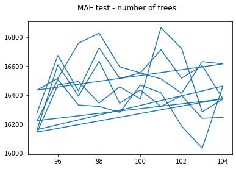

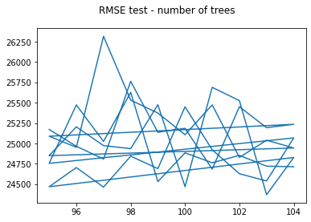

```python
import matplotlib.pyplot as plt
plt.figure().suptitle('MAE test - number of trees')
plt.plot(ns, MAEtest)
plt.figure().suptitle('RMSE test - number of trees')
plt.plot(ns, RMSEtest)
```

#### Voting Regression

```python
from sklearn.ensemble import VotingRegressor

# read
train_data = pd.read_csv("train.csv")

# hande missing data
train_data = train_data.drop(columns=['PoolQC', 'MiscFeature', 'Alley', 'Fence', 'FireplaceQu'])
for i in ['LotFrontage', 'MasVnrArea', 'GarageYrBlt']:
    train_data[i].fillna(train_data[i].mean(), inplace=True)
for i in ['MasVnrType', 'Electrical']:
    train_data[i].fillna(train_data[i].value_counts().index[0], inplace=True)
for i in train_data:
    train_data[i].fillna("NO_DATA", inplace=True)

# handle categorical data
categorical_columns = train_data.select_dtypes('object')
train_data = ce.OneHotEncoder(cols=categorical_columns, use_cat_names=True).fit_transform(train_data)

# standardization and normalization
x = train_data.iloc[:, :-1].values
target = train_data['SalePrice'].values

# split to train and test
x_train, x_test, y_train, y_test = train_test_split(x, target, test_size=0.20)

# Voting Regression algorithm
kNeighborsRegressor = KNeighborsRegressor(n_neighbors=13)
decisionTreeRegressor = DecisionTreeRegressor(max_depth=15)
linearRegression = LinearRegression()
votingRegressor = VotingRegressor([('knn', kNeighborsRegressor), ('dt', decisionTreeRegressor), ('lr', linearRegression)])
votingRegressor.fit(x_train, y_train)
train_prediction = votingRegressor.predict(x_train)
test_prediction = votingRegressor.predict(x_test)

# print result
print("Train MAE: ", mean_absolute_error(train_prediction, y_train))
print("Train RMSE: ", np.sqrt(mean_squared_error(train_prediction, y_train)))
print("######################################")
print("Test MAE: ", mean_absolute_error(test_prediction, y_test))
print("Test RMSE: ", np.sqrt(mean_squared_error(test_prediction, y_test)))
```

```
Train MAE:  11576.552850529733
Train RMSE:  18976.31156197661
######################################
Test MAE:  18300.979495936936
Test RMSE:  28312.93765405251
```